## Lecture 9 : Private Equity

# Alternative Investments Introduction

- Let’s broaden the scope of the investable universe
  - Private equity, hedge funds, fixed income and derivatives
- Everything we learned in first half of class applies, but…
  - Data is more opaque
  - Liquidity is a bigger issue
  - Institutional details matter more
    - E.g. Lock-up periods, redemption, fee structure
  - Efficiency (maybe?)

# Private Equity

- What is Private Equity (PE)?
- A PE fund is a financial intermediary typically formed as limited partnerships
  - General Partner (GP): Manage funds, make investments
  - Limited Partners (LPs): Passive investors (pension funds, endowments)
- A PE fund invests only in private (or soon-to-be-private) companies
  - Costs: information asymmetry and illiquidity
  - Benefits: control

# Private Equity

- A PE fund takes an *active* role in the firm
  - Added value through management/monitoring
- A PE fund has an exit strategy
  - Because of illquidity of investment, targets must provide a clear path to exit (e.g. IPO or sale to another company)
  - Funds are closed-end with lifespans of 10-12 years
    - Commitments raised
    - Capital calls/investments made
    - “Harvesting” period

# Venture Capital

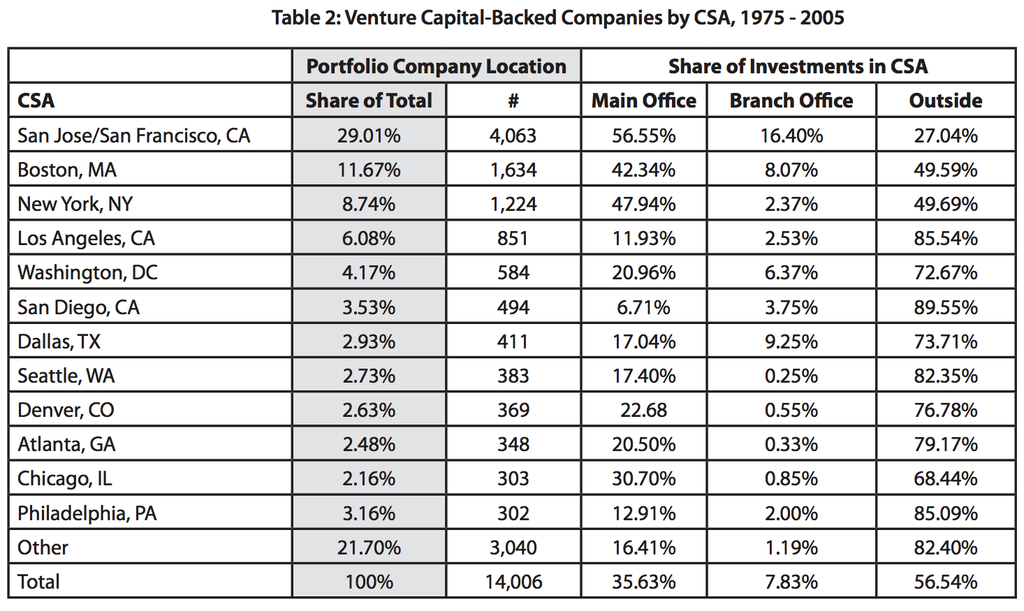

# What value does Venture Capital add?

1. Screening:
   - VCs as winner-pickers – select 1-in-400 deals to fund
   - Do VCs bet the jockey or the horse?
   - High management turnover suggests the horse
2. Advising/Monitoring:
   - Requires control rights
   - Investments typically include voting rights, board seats, esp. in bad times
3. Exit

*Important to have good VCs for good returns!*

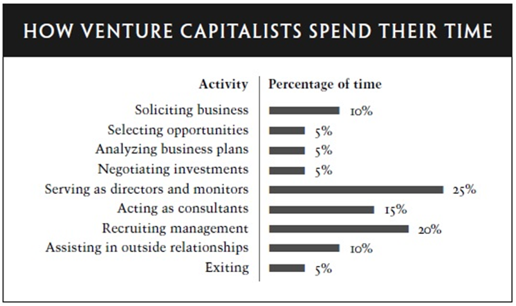

# Buyout Funds

- In contrast to VC, (Leveraged) Buyout (BO) funds focus on established firms
- Firms are either private to begin with, or are taken private (as in a management buyout)
- Large amounts of *new* debt are used to finance the repurchase of existing equity
  - Often 90/10 debt-to-equity ratio in new company
  - Example: RJR Nabisco, Dell

# Buyout Funds

- Where does the value-add come from?
  - No need to take company private to exploit an undervalued stock
  - Similar to VC, control must matter
- What types of things do LBO firms do once they have control that adds value?
  - Spin-offs of conglomerates
    - Beatrice Foods
  - Efficiency gains (cost-cutting, union negotiations, layoffs)
    - Safeway

# Or is it just leverage?

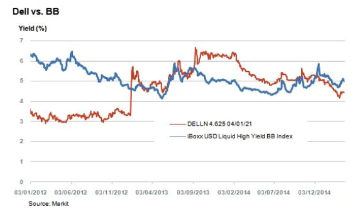

# Private Equity Fund Contracts

- Incentives of GPs and LPs may not always be aligned
- GPs may have incentives to shirk or take excessive risk
- Fees, co-investment by fund managers and covenants discipline GPs and protect the LPs

# Private Equity Fund Contracts

- *Fees* include a flat rate (1-3%) plus 20-30% performance fee
- *Co-investment*: General partners often required to personally invest in the funds (typically GP invests 1%)
- *Covenants*: e.g. restrictions on activities

# Private Equity Fund Covenants

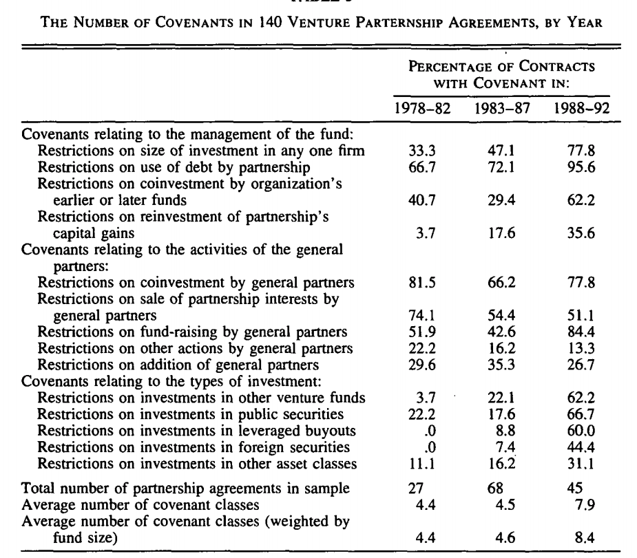

# Private Equity Performance

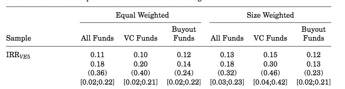

- Table reports mean, median, standard deviations and 25-75th percentile of dollar weighted returns (IRR) to PE funds
  - Why dollar-weighted returns?
  - On average, roughly equivalent to S&P500 during same period (net of fees)

# Private Equity Performance

- How to identify good private equity funds?
- Pick past winners! (What?)
- Returns to private equity are highly persistent (Why?)
- Issue: everyone wants to get in funds with strong performance
  - Who gets access?
  - What incentive effects does this create?

# Private Equity Performance

## Determinants of fund performance (Private Market Equivalents)

- General Partner (PE funds) performance is persistent

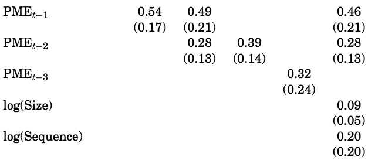

# Private Equity Performance and Other Issues

- Often the binding constraint for successful PE funds is investment opportunities, not investors
- Leads to money-chasing-deals phenomenon
- During periods of high flows into private equity, funds pay higher valuations for their acquisitions

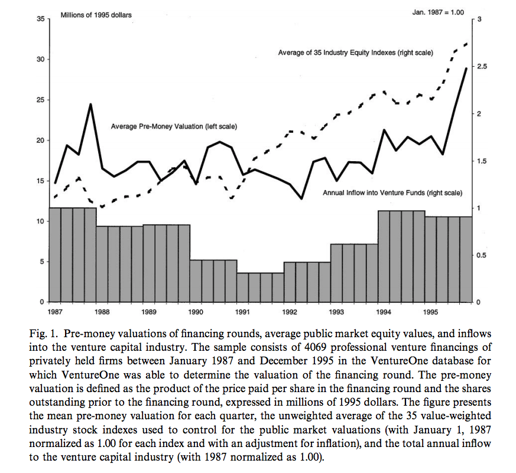

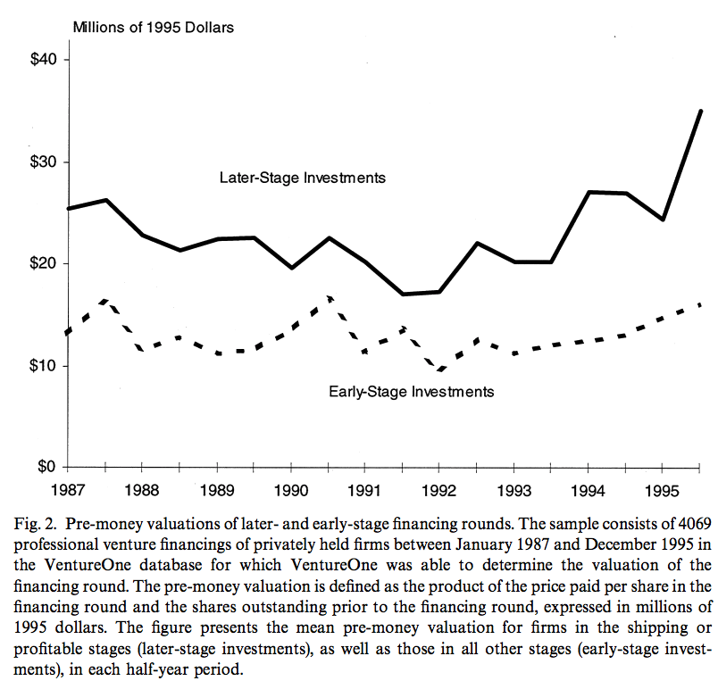